# *Motor Trend* - Report (12/10/2019)

# Summary

We are looking at a dataset of a collection of cars to explore the relationship between a set of variables defining the design and performance of the cars, and their miles per gallon (MPG) output. We are particularly interested in the following two questions:

1. Is an automatic or manual transmission better for MPG?
2. How can we quantify the MPG difference between automatic and manual transmissions?

For this analysis, a simple regression model was applied, selecting the best fitting parameters for an approximate estimation of the outcome.

# Data Preprocessing

We load the data (the **mtcars** package in R) and the required libraries, and look at the variables

```r
data(mtcars)
library(ggplot2)
str(mtcars)
```

```
## 'data.frame':    32 obs. of  11 variables:
##  $ mpg : num  21 21 22.8 21.4 18.7 18.1 14.3 24.4 22.8 19.2 ...
##  $ cyl : num  6 6 4 6 8 6 8 4 4 6 ...
##  $ disp: num  160 160 108 258 360 ...
##  $ hp  : num  110 110 93 110 175 105 245 62 95 123 ...
##  $ drat: num  3.9 3.9 3.85 3.08 3.15 2.76 3.21 3.69 3.92 3.92 ...
##  $ wt  : num  2.62 2.88 2.32 3.21 3.44 ...
##  $ qsec: num  16.5 17 18.6 19.4 17 ...
##  $ vs  : num  0 0 1 1 0 1 0 1 1 1 ...
##  $ am  : num  1 1 1 0 0 0 0 0 0 0 ...
##  $ gear: num  4 4 4 3 3 3 3 4 4 4 ...
##  $ carb: num  4 4 1 1 2 1 4 2 2 4 ...
```

We look at the data and the correlation values for some clarity. We can see that some variables will provide better estimations if they are converted to factors. So we perform the conversion.

```r
correl <- cor(mtcars$mpg, mtcars[,-1])
?mtcars
mtcars$cyl <- as.factor(mtcars$cyl)
mtcars$vs <- as.factor(mtcars$vs); levels(mtcars$vs) <- c("V-shaped", "Straight")
mtcars$am <- as.factor(mtcars$am); levels(mtcars$am) <- c("Auto", "Manual")
mtcars$gear <- as.factor(mtcars$gear)
mtcars$carb <- as.factor(mtcars$carb)
```

# Exploratory Analysis

We perform some exploratory analysis and draw some plots to understand realtions among the variables better. These plots are provided for reference in the appendix.

```r
pairs(mpg ~ ., data = mtcars)
plot(mtcars$am, mtcars$mpg)
summary(mtcars)
```

[output not shown]

# Data Analysis

We perform a multivariate linear regression to fit the data.

First, we make the model to evaluate the relationship between MPG and Transmission. We use a stepwise backwards selection to achieve the best fitting model for our data.

```r
set.seed(1234)
model1 <- lm(mpg ~ ., data = mtcars)
model2 <- lm(mpg ~ cyl + disp + hp + wt + vs + am, data = mtcars)
best.model <- step(model1, direction = "backward")
```

```r
summary(best.model)
```

```
##
## Call:
## lm(formula = mpg ~ cyl + hp + wt + am, data = mtcars)
##
## Residuals:
##     Min      1Q  Median      3Q     Max
## -3.9387 -1.2560 -0.4013  1.1253  5.0513
##
## Coefficients:
##             Estimate Std. Error t value Pr(>|t|)
## (Intercept) 33.70832    2.60489  12.940 7.73e-13 ***
## cyl6        -3.03134    1.40728  -2.154  0.04068 *
## cyl8        -2.16368    2.28425  -0.947  0.35225
## hp          -0.03211    0.01369  -2.345  0.02693 *
## wt          -2.49683    0.88559  -2.819  0.00908 **
## amManual     1.80921    1.39630   1.296  0.20646
## ---
## Signif. codes:  0 '***' 0.001 '**' 0.01 '*' 0.05 '.' 0.1 ' ' 1
##
## Residual standard error: 2.41 on 26 degrees of freedom
## Multiple R-squared:  0.8659, Adjusted R-squared:  0.8401
## F-statistic: 33.57 on 5 and 26 DF,  p-value: 1.506e-10
```

Then, we quantify the relationship between MPG and Transmission type. The plot is included in the Appendix.

```r
plot(mtcars$am, mtcars$mpg, main = "MPG vs. Transmission Type", ylab = "MPG")
t.test(mpg ~ am, data = mtcars)
```

```
##
##  Welch Two Sample t-test
##
## data:  mpg by am
## t = -3.7671, df = 18.332, p-value = 0.001374
## alternative hypothesis: true difference in means is not equal to 0
## 95 percent confidence interval:
##  -11.280194  -3.209684
## sample estimates:
##   mean in group Auto mean in group Manual
##             17.14737             24.39231
```

# Results

The appendix includes additional material for this report.

# Appendix

## Exploratory Plots

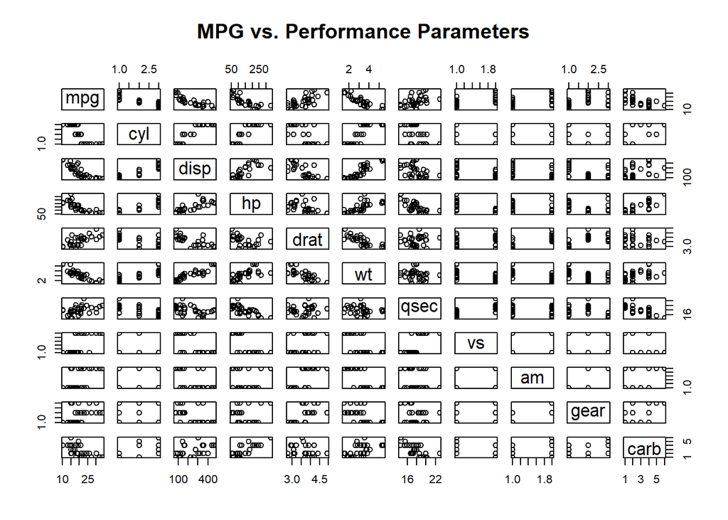

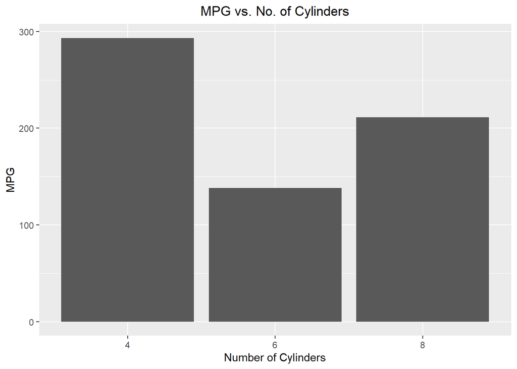

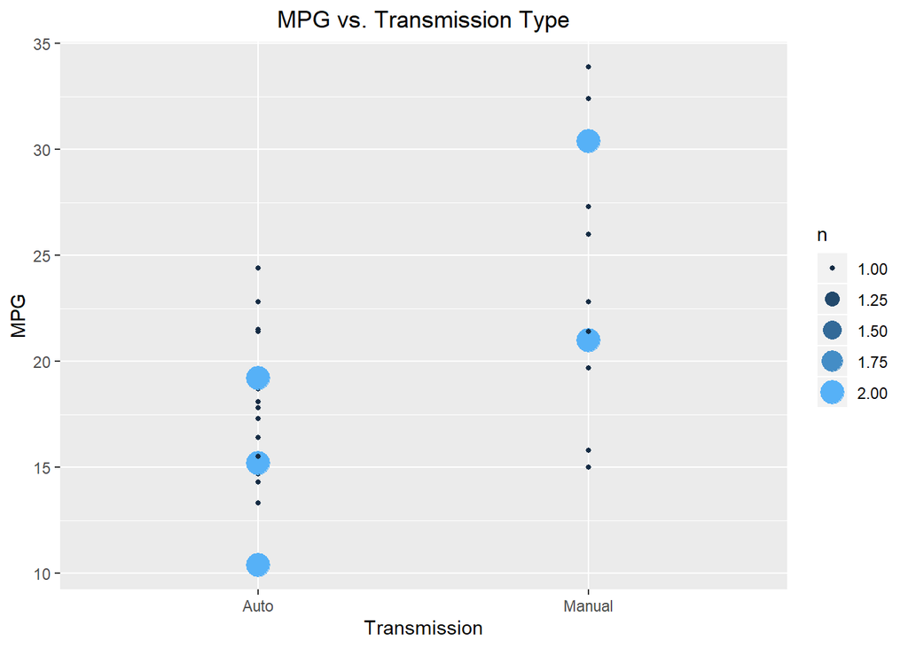

## MPG vs. Transmission Type - BoxPlot

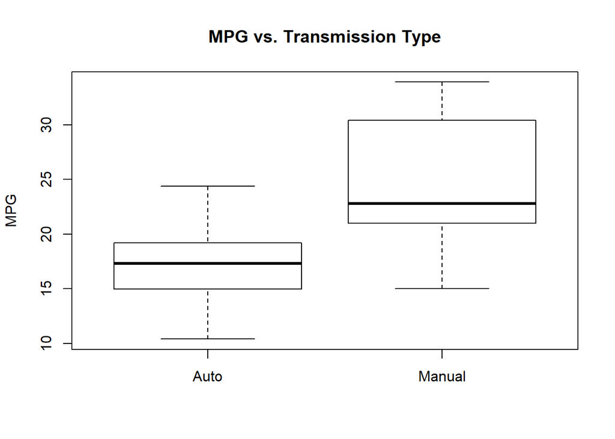

## Residals and Diagnostics

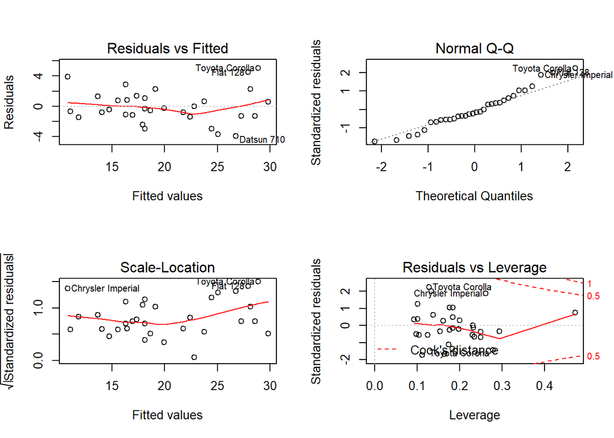

```r
hatvalues <- round(hatvalues(best.model),3)
dfbetas <- round(dfbetas(best.model),3)
```

This is the end of our analysis.

### Regression Models - Project 1 (12-10-2019)